# Genomic Surveillance of Hospital-Associated Bacterial and Fungal Infections at the Washington State Public Health Laboratory

# Bacterial Surveillance

## Bacterial Sequencing Overview

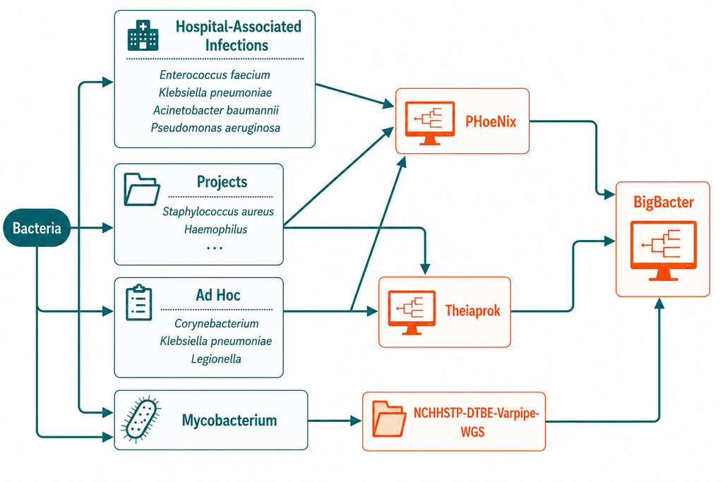

## Phoenix vs TheiaProk

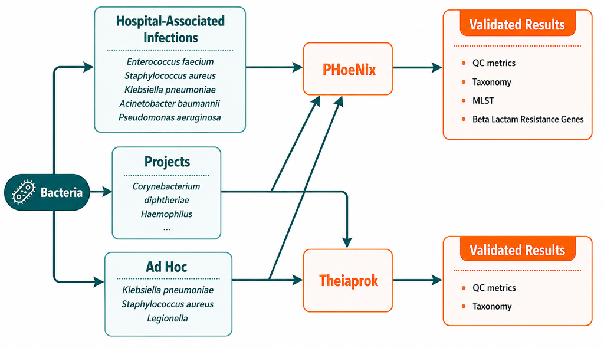

## Bacterial Dataflow

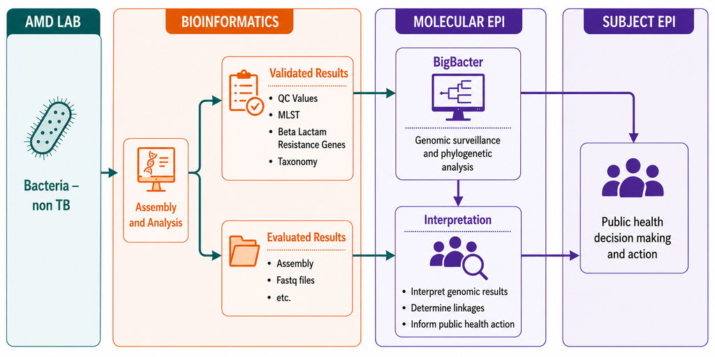

## Pipeline Output: HAI Bacteria

### PHoeNix

| ID | Auto_QC_Status | Species | MLST_Scheme_1 | MLST_1 | MLST_Scheme_2 | MLST_2 | GAMMA_Beta_Lactamase | Auto_QC_Result |
| --- | --- | --- | --- | --- | --- | --- | --- | --- |
| VeryRealSample_01 | PASS | Pseudomonas aeruginosa | paeruginosa | ST654 | - | - | blaNDM-1_NG_049326 | PASS |
| VeryRealSample_02 | PASS | Acinetobacter baumannii | abaumannii | ST955 | abaumannii | ST126 | Mbl_NC_010410,Zn-dep_hydrolase | PASS |
| VeryRealSample_03 | PASS | Klebsiella pneumoniae | klebsiella | ST147 | - | - | ampH_CP003785,blaCTX-M-15 | PASS |
| VeryRealSample_04 | PASS | Escherichia coli | ecoli(Achtman) | ST410 | ecoli_2(Pasteur) | ST471 | AmpC1_Ecoli_FN649414,blaCTX-M-15 | PASS |
| VeryRealSample_05 | PASS | Acinetobacter baumannii | abaumannii | ST2535-PA | abaumannii | ST2 | Mbl_NC_010410,Zn-dep_hydrolase | PASS |

### BigBacter

| id | run | status | included | taxa | cluster | partition | strong_links | inter_links | genome_fr | core_fract | length | masked | missing | mixed | variants | recomb_m | max_snp_c | mean_snp | min_snp_d |
| --- | --- | --- | --- | --- | --- | --- | --- | --- | --- | --- | --- | --- | --- | --- | --- | --- | --- | --- | --- |
| RealSample | 1.78E+09 | new | TRUE | Shigella_sc | 1 | 34 | RealSample03:RealSample | WA100150 | 0.994833 | 0.994833 | 5057083 | 0 | 26130 | 0 | 8 | FALSE | 580 | 232 | 0 |
| RealSample | 1.78E+09 | new | TRUE | Shigella_sc | 1 | 40 | RealSample05 | WA100150 | 0.964828 | 0.961383 | 5057083 | 0 | 177861 | 0 | 12 | FALSE | 586 | 236 | 1 |
| RealSample | 1.78E+09 | new | TRUE | Shigella_sc | 1 | 34 | RealSample01:RealSample | WA100150 | 0.964795 | 0.961146 | 5057083 | 0 | 178027 | 0 | 8 | FALSE | 584 | 234 | 0 |
| RealSample | 1.78E+09 | new | TRUE | Shigella_sc | 1 | 34 | RealSample01:RealSample | WA100150 | 0.964756 | 0.960951 | 5057083 | 0 | 178224 | 0 | 8 | FALSE | 584 | 234 | 0 |

## Pipeline Output: HAI Bacteria

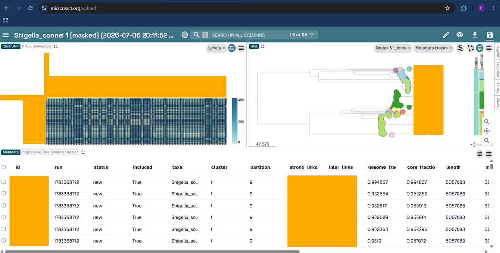

## Bacterial Logistics

|  | HAI Bacteria | Non-HAI Bacteria |
| --- | --- | --- |
| **Pipeline** | PHoeNIx* |  |
| **Frequency** | ~35-45 seqs/ 2x month | ~1-8 seqs/ week |
| **Typical TAT** | 1-2 business days*** |  |
| **Compute Resources** | AWS + Seqera |  |

|  | HAI Bacteria | Non-HAI Bacteria |
| --- | --- | --- |
| **Pipeline** | BigBacter** |  |
| **Frequency** | ~3-19 seqs/ 2x month | ~1-8 seqs/ week |
| **Typical TAT** | 1-2 business days*** |  |
| **Compute Resources** | AWS + Seqera |  |

- [*PHoeNIx](https://github.com/CDCgov/phoenix)
- [**BigBacter](https://github.com/NW-PaGe/bigbacter)
- ***Prioritized based on epi needs

# Fungal Surveillance

## Fungal Dataflow

[figure not shown]

- WA PHL’s only routine fungal bioinformatics workflow is for *Candidozyma auris* WGS, for the AR Lab Network
- WA PHL Bioinformatics can provide analyses for other fungi on an ad-hoc basis

## Fungal Logistics

|  | Candida auris |
| --- | --- |
| **Pipeline** | CorgiSNPs* |
| **Frequency** | ~20-30 seqs/ 2x month |
| **Typical TAT** | 1-2 business days |
| **Compute Resources** | AWS + Seqera |

- *CorgiSNPs currently undergoing validation. [MycoSNP](https://github.com/CDCgov/mycosnp-nf) is used for production runs currently.

## Pipeline Output: *Candida auris*

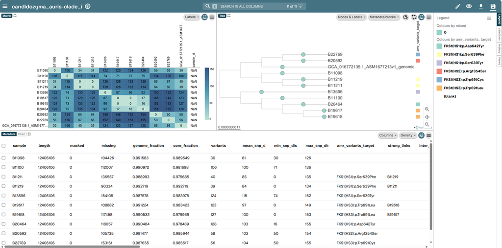

## Summary

Genomic analysis of hospital associated infections can be split into two primary analyses - **sample**-level and **population**-level - each requiring different quality control considerations!

#### Bacteria

- **PHoeNIx** for per-sample QC, typing, and AMR gene detection
- **BigBacter** for clustering and core-SNP phylogenies
- HAI: ~35–45 seqs 2×/month · Non-HAI: ~1–8 seqs/week

#### Fungi

- Routine workflow is *Candidozyma auris* WGS only — other fungi are **ad-hoc**
- **MycoSNP** in production; **CorgiSNPs** in validation
- ~20–30 seqs 2×/month

#### Both

- **1–2 business day TAT** and prioritized by epi need.
- Interpretation is generally the bottleneck, not computational analysis

# Questions?

**Contact:** waphl-bioinformatics@doh.wa.gov